# Análise de dados

Marisangila Alves

08/14/2021

### Parâmetros

```
      Parâmetros      | Valores
----------------------|----------
alfa                  | 0, 0.5, 1
lambda                | 5
n                     | 100
beta                  | 0.2
BS                    | 32
Cache                 | 100
UE                    | 200
Resources             | MBS 100 SBS 50
Average               | MBS 300 SBS 70
RTT inicial           | MBS/MBS 05 s MBS/SBS 10 SBS/UE 15/20
Tempo da Requisição   | 10 eventos
Mobilidade            | -2,2 unidades de distância
```

### Informações da Aplicação.

```
  Vazão Mínima | Tamanho de Unidade de Cache | Número de Unidades de Cache | Número de Unidades de Recursos
---------------|-----------------------------|-----------------------------|-------------------------------
   45 Mbps     |      169 MB (1350Mbp)      |             30s              |             5
```

### Tempo de execução da otimização.

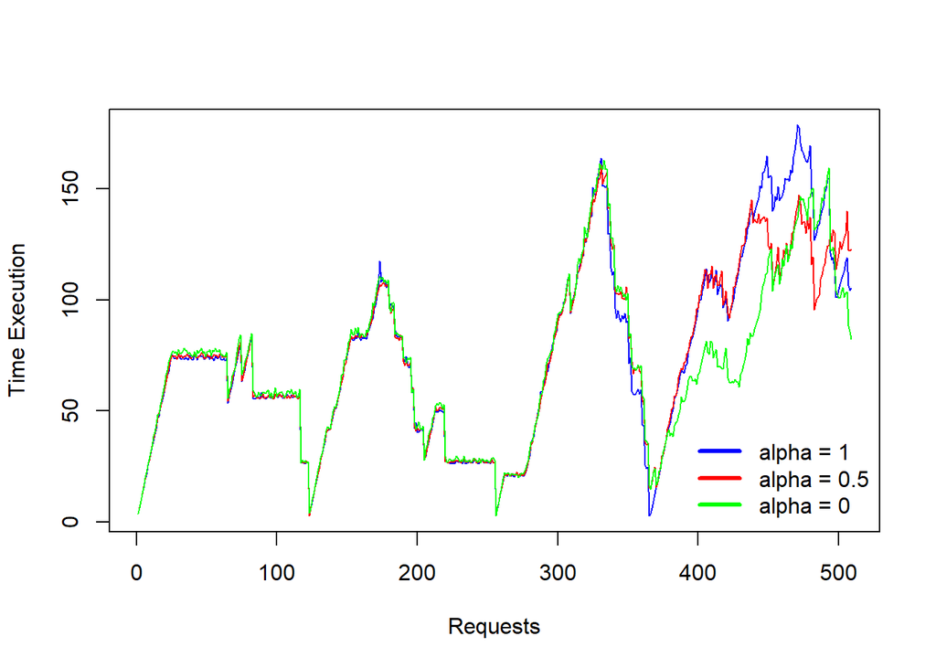

### Distribuição das Requisições.

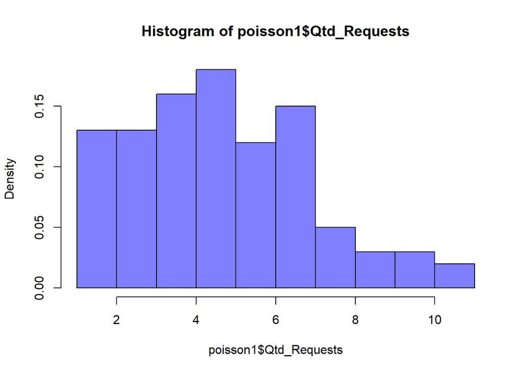

### Distribuição de popularidade do conteúdo solicitado.

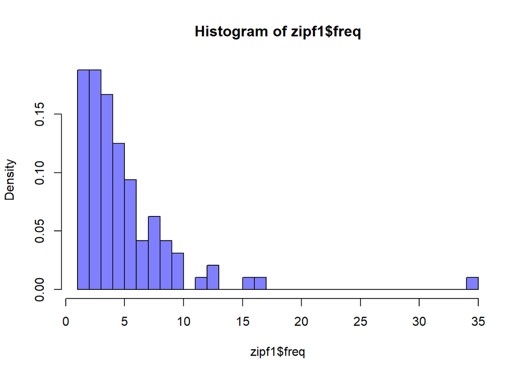

### Taxa de requisições alocadas.

$\alpha : 1 =$ 53.44% - 272/509.

$\alpha : 0.5 =$ 52.85% - 269/509.

$\alpha : 0 =$ 48.33% - 246/509.

### Uso de servidor por evento.

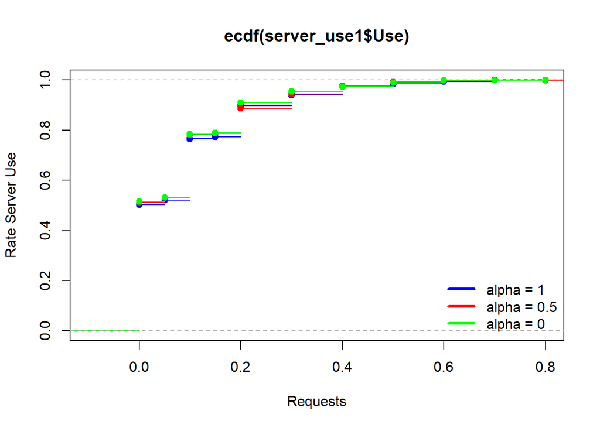

### Fraguimentação de enlaces sem fio por evento.

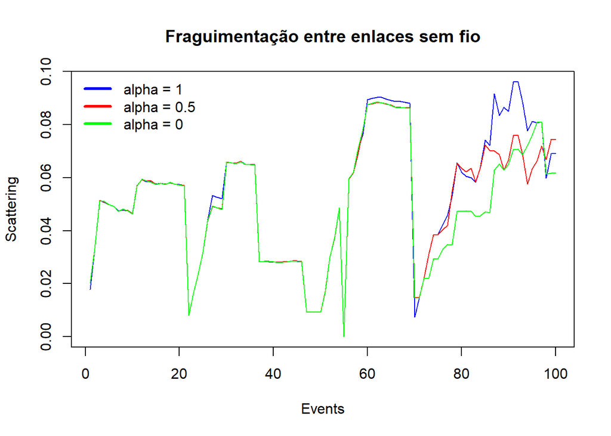

### Significância entre amostras (Teste T não pareado).

*Um valor de p menor que 0.05 indica que a diferença é estatisticamente significativa.*

A diferença entre alfa 1 e alfa 0.5 **não é** estatisticamente significativa. Valor de p: 0.5450566.

### Fraguimentação de enlaces ópticos por evento.

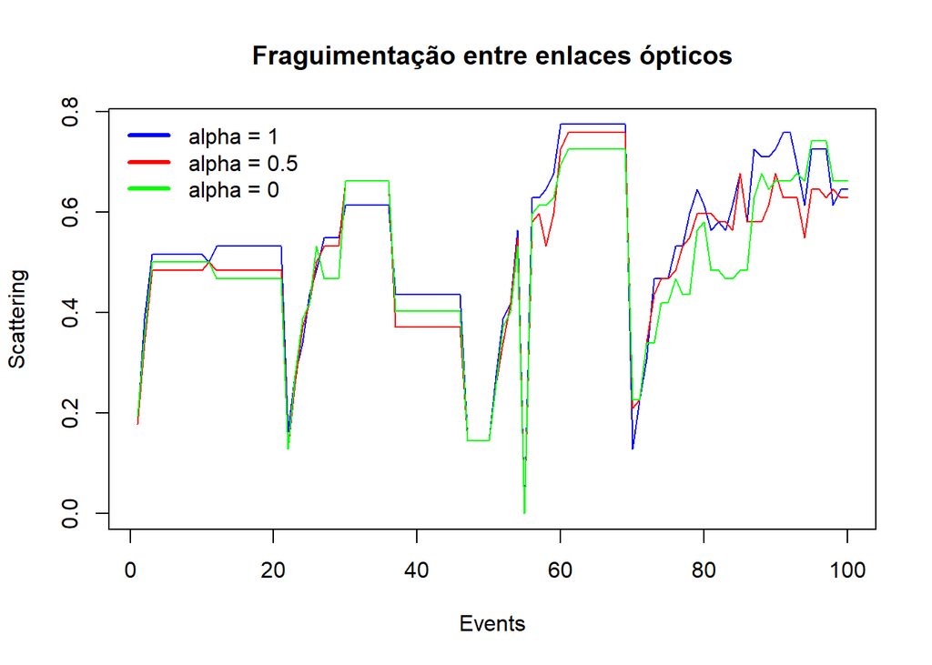

### Significância entre amostras (Teste T não pareado).

*Um valor de p menor que 0.05 indica que a diferença é estatisticamente significativa.*

A diferença entre alfa 1 e alfa 0.5 **não é** estatisticamente significativa. Valor de p: 0.2350569.

### Carga média de enlaces sem fio por evento.

```
##    Min. 1st Qu.  Median    Mean 3rd Qu.    Max.
##   45.00   45.00   48.00   48.04   49.69   54.00
```

```
##    Min. 1st Qu.  Median    Mean 3rd Qu.    Max.
##   45.00   46.32   48.46   48.34   50.16   54.00
```

```
##    Min. 1st Qu.  Median    Mean 3rd Qu.    Max.
##   45.00   45.00   48.00   48.26   50.22   55.66
```

```
##    Min. 1st Qu.  Median    Mean 3rd Qu.    Max.
##      45      45      45      45      45      45
```

```
##    Min. 1st Qu.  Median    Mean 3rd Qu.    Max.
##      45      45      45      45      45      45
```

```
##    Min. 1st Qu.  Median    Mean 3rd Qu.    Max.
##      45      45      45      45      45      45
```

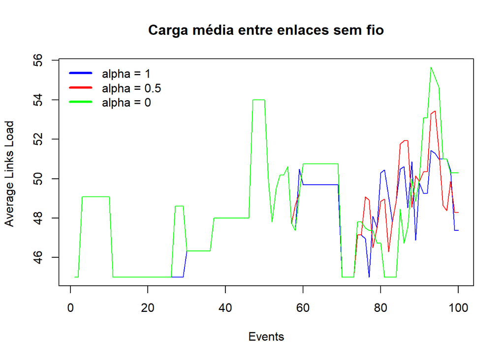

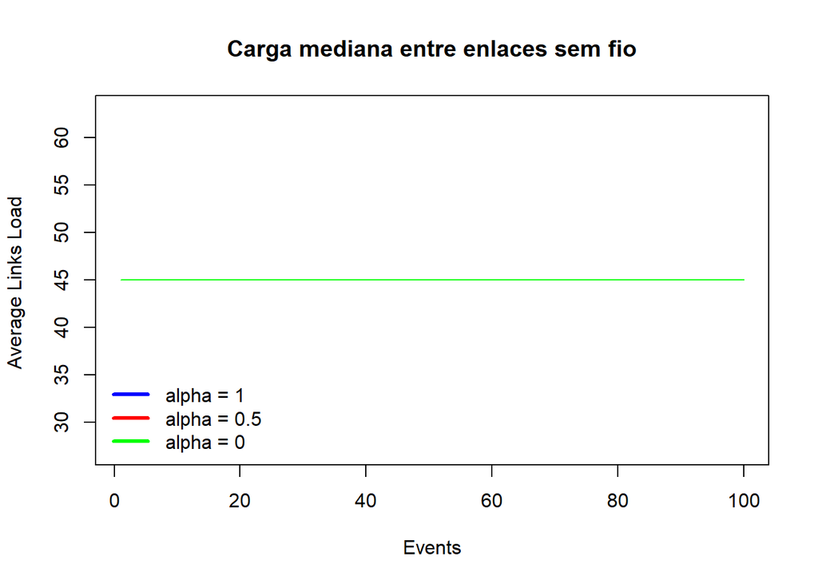

### Significância entre amostras (Teste T não pareado).

*Um valor de p menor que 0.05 indica que a diferença é estatisticamente significativa.*

**Entre médias:**

A diferença entre alfa 1 e alfa 0.5 **não é** estatisticamente significativa. Valor de p: 0.3836484.

A diferença entre alfa 1 e alfa 0 **não é** estatisticamente significativa. Valor de p: 0.5359775.

A diferença entre alfa 0.5 e alfa 0 **não é** estatisticamente significativa. Valor de p: 0.8413057.

### Carga média de enlaces sem ópticos por evento.

```
##    Min. 1st Qu.  Median    Mean 3rd Qu.    Max.
##   45.00   73.73   92.73   92.22  111.70  139.00
```

```
##    Min. 1st Qu.  Median    Mean 3rd Qu.    Max.
##   45.00   69.04   82.32   81.78   95.62  113.75
```

```
##    Min. 1st Qu.  Median    Mean 3rd Qu.    Max.
##   45.00   65.00   80.01   78.58   86.72  110.93
```

```
##    Min. 1st Qu.  Median    Mean 3rd Qu.    Max.
##   45.00   45.00   67.50   65.47   90.00   90.00
```

```
##    Min. 1st Qu.  Median    Mean 3rd Qu.    Max.
##    45.0    45.0    45.0    60.3    90.0    90.0
```

```
##    Min. 1st Qu.  Median    Mean 3rd Qu.    Max.
##   45.00   45.00   45.00   56.92   90.00   90.00
```

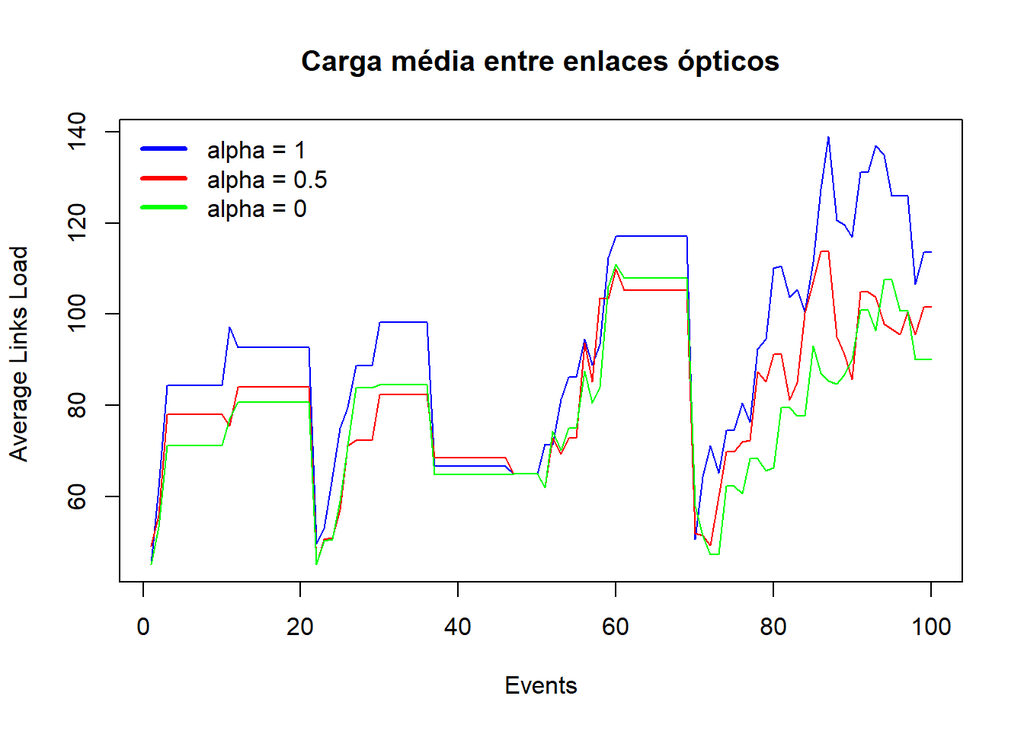

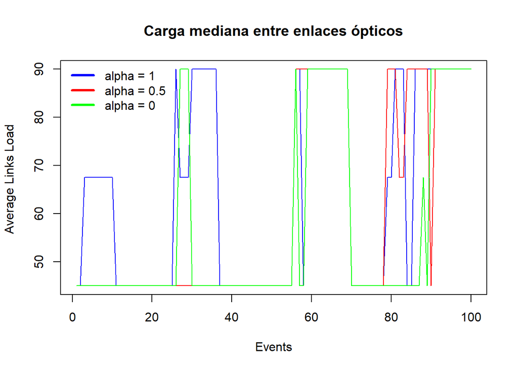

### Significância entre amostras (Teste T não pareado).

*Um valor de p menor que 0.05 indica que a diferença é estatisticamente significativa.*

**Entre médias:**

A diferença entre alfa 1 e alfa 0.5 **é** estatisticamente significativa. Valor de p: 2.356428110^{-4}.

A diferença entre alfa 1 e alfa 0 **é** estatisticamente significativa. Valor de p: 2.171377910^{-6}.

A diferença entre alfa 0.5 e alfa 0 **não é** estatisticamente significativa. Valor de p: 0.1793815.

### Número de Realocação de Enlaces por Requisição

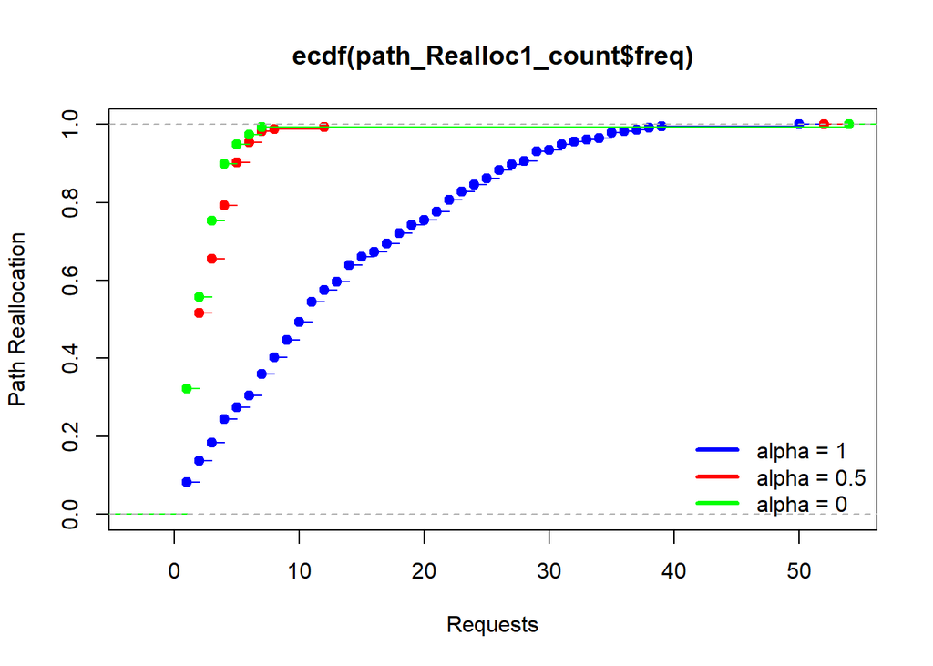

### Número de Realocação de Servidor por Requisição

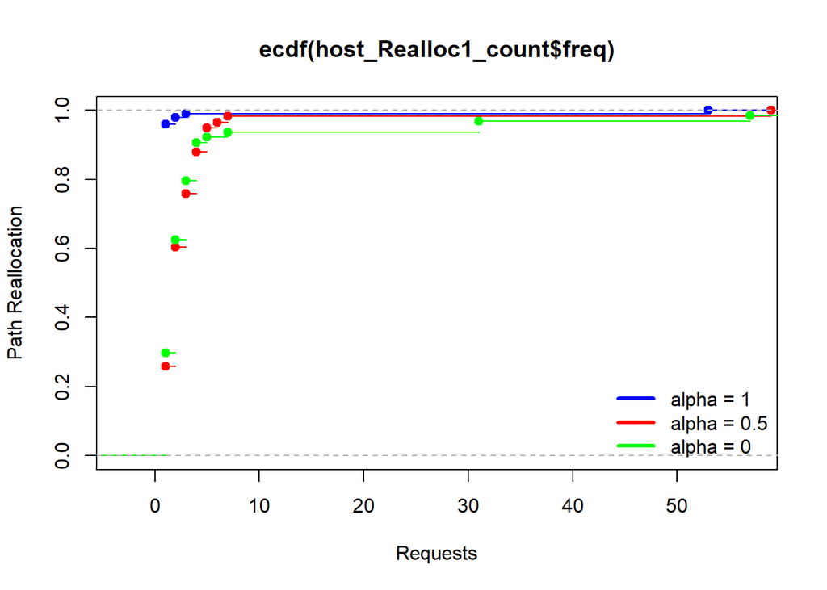

### Número de Realocação de Enlaces por Evento

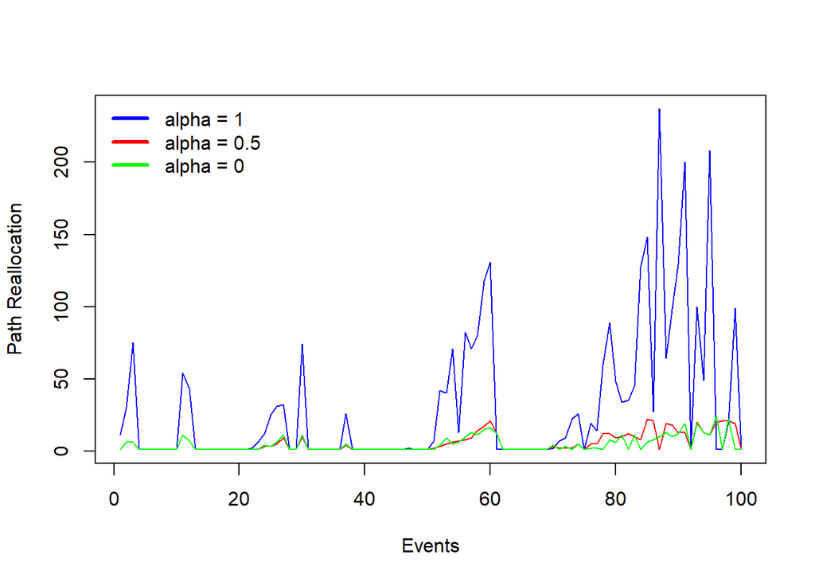

### Significância entre amostras (Teste T não pareado).

*Um valor de p menor que 0.05 indica que a diferença é estatisticamente significativa.*

A diferença entre alfa 1 e alfa 0.5 **é** estatisticamente significativa. Valor de p: 1.850098610^{-6}.

A diferença entre alfa 1 e alfa 0 **é** estatisticamente significativa. Valor de p: 7.59440410^{-7}.

A diferença entre alfa 0.5 e alfa 0 **não é** estatisticamente significativa. Valor de p: 0.236939.

### Número de Realocação de Servidor por Evento

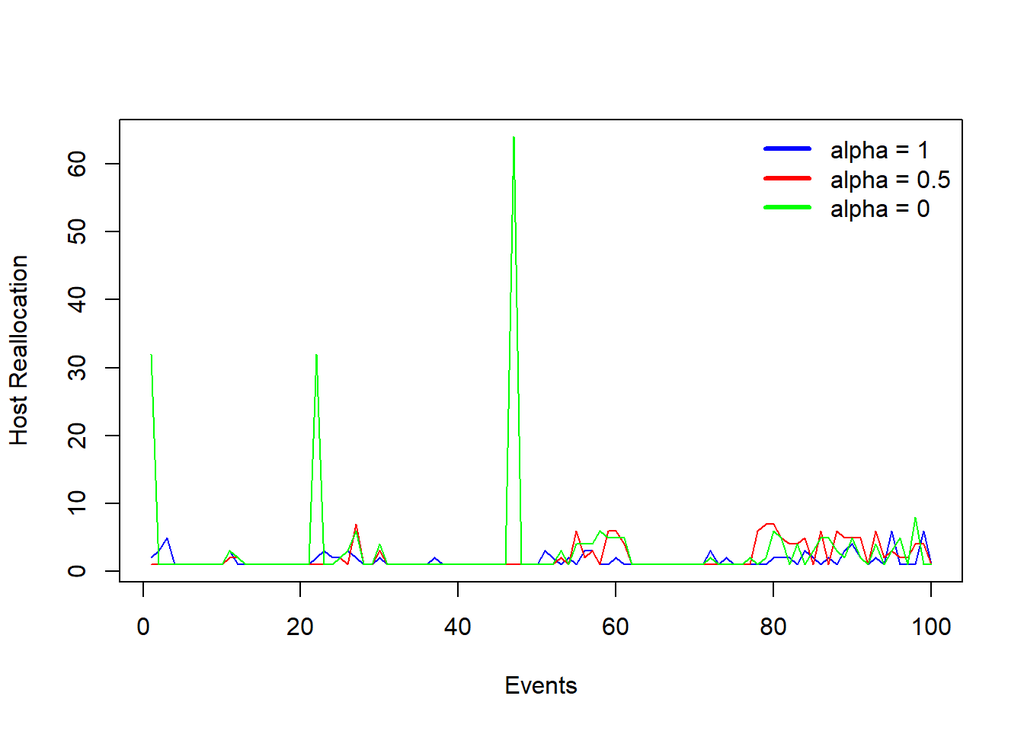

### Significância entre amostras (Teste T não pareado).

*Um valor de p menor que 0.05 indica que a diferença é estatisticamente significativa.*

A diferença entre alfa 1 e alfa 0.5 **é** estatisticamente significativa. Valor de p: 0.0249608.

A diferença entre alfa 1 e alfa 0 **é** estatisticamente significativa. Valor de p: 0.0389182.

A diferença entre alfa 0.5 e alfa 0 **não é** estatisticamente significativa. Valor de p: 0.1487786.

### Testes de Correlação Kendall

**Correlação entre migração de servidores e caminhos.** Valor de p: 0.599142.

Correlação entre carga média dos enlaces sem fio e migração de caminhos. Valor de p: 0.1016643.

Correlação entre carga média dos enlaces ópticos e migração de caminhos. Valor de p: 0.1710861.

Correlação entre carga média dos enlaces ópticos e migração de servidores. Valor de p: 0.0119638.